# Project_Prosper_Loan_Data_Analysis.slides Explanatory

## Udacity Project Prosper Loan Data Visualization (May 2019)

### Karen Chang

```python
# import all packages and set plots to be embedded inline
import numpy as np
import pandas as pd
import matplotlib.pyplot as plt
import seaborn as sb

%matplotlib inline
```

```python
prosper = pd.read_csv('prosper_cleandata', parse_dates=['ListingCreationDate', 'ClosedDate', 'DateCreditPulled', 'LoanOriginationDate'])
prosper.shape
```

```
(113066, 86)
```

### Data Structure

This data is provided by Udacity and the original dataset contains 113,937 loans with 81 variables, including loan amount, borrower rate, current loan status, borrower income, and etc. After removing duplicated items and adding new variables, the current dataset contains 113,066 loans with 86 variables. The period of this data set is for loans created during Nov 2005 and March 2014.

### Objectives

In this project, we will perform data analysis to help Prosper to:

*1) Increase the profitability on future loans.*

*2) Grow revenue by having better targeting on potential good customers in the future.*

### Main Features to Investigate

1) **loan profit** : It's calculated as: LenderYield * LoanOriginalAmount – AmountDelinquent

2) **Credit Rating**: The credit rating is a crucial indicator to classify borrowers. We would like to investigate the appropriateness of credit rating calssified at Prosper.

### Plot 1 **StatedMonthlyIncome**

It's the monthly income the borrower stated at the time the listing was created.

A distribution plot is performed according to data with percentile 95% (USD 12,250). The data has the shape of a normal distribution with slight right skewed trend indicates with peak at around USD 4,000 with mean USD 4,919 and median USD 4,543.

According to https://www.worlddata.info/average-income.php which provides world average salary per 2017, the average monthly salary in USA is USD 4,930. We can see that people with monthly salary lower than USD 5,000 are highly possible to apply loans.

```python
a = prosper['StatedMonthlyIncome']
np.percentile(a,95);
```

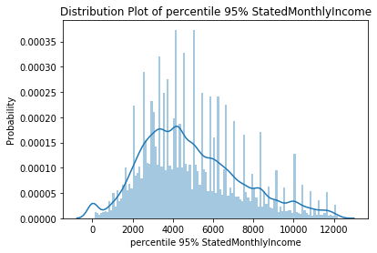

```python
bins = np.arange(100, 12250,100)
prosper_95monthlyincome = prosper.query('StatedMonthlyIncome < 12250').StatedMonthlyIncome
sb.distplot(prosper_95monthlyincome, bins, axlabel = 'percentile 95% StatedMonthlyIncome')
plt.title('Distribution Plot of percentile 95% StatedMonthlyIncome')
plt.xlabel('percentile 95% StatedMonthlyIncome')
plt.ylabel('Probability');
```

```python
prosper_95monthlyincome.describe()
```

```
count    107402.000000
mean       4919.007018
std        2487.310003
min           0.000000
25%        3116.666667
50%        4543.125000
75%        6416.666667
max       12241.666667
Name: StatedMonthlyIncome, dtype: float64
```

### Plot 2 **loanprofit**

It's the difference between **LenderYield** * **LoanOriginalAmount** and **AmountDelinquent**.

We noted 4,635 exceptional cases where **LoanOriginalAmount** is lower than **AmountDelinquent**. Thus after dropping these exceptions, the distribution plot is slightly right skewed and shows that the majority of loanprofit is under USD 2,000 with median USD 1,099 and mean USD 1,257. Thus, for each loan, we may expect to have gain for around USD 1-2K.

In the next section, we will investigate further about the relationship between **loanprofit** and other variables.

```python
prosper.query('ReasonableResult == True')['loanprofit'].describe()
```

```
count    108431.000000
mean       1257.156273
std        1191.191706
min      -19285.500000
25%         574.500000
50%        1099.600000
75%        1870.000000
max        8500.000000
Name: loanprofit, dtype: float64
```

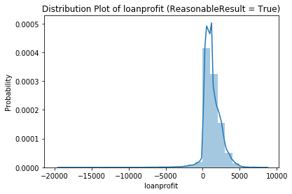

```python
prosper_reasonable_loanprofit = prosper.query('ReasonableResult == True')['loanprofit']
bins = np.arange(-20000, prosper_reasonable_loanprofit.max(),1000)
sb.distplot(prosper_reasonable_loanprofit, bins)
plt.title('Distribution Plot of loanprofit (ReasonableResult = True)')
plt.xlabel('loanprofit')
plt.ylabel('Probability');
```

### Plot 3 **BorrowerState**

In total, there are 51 states where all the borrowers are located. Based on the histogram plot, we can see CA (California) is the state with highest number of loans (12% of total number of loans). It’s reasonable as headquarter of Prosper is located at CA. TX is at the second place, followed by FL, NY and IL. These states have individually approximate 6% of total number of loans.

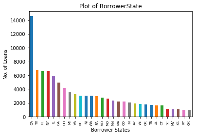

```python
prosper_statesloan = prosper.groupby('BorrowerState').ListingKey.count().sort_values(ascending = False).head(30)
prosper_statesloan.plot(kind='bar')
plt.title('Plot of BorrowerState')
plt.xlabel('Borrower States')
plt.ylabel('No. of Loans')
plt.xticks(fontsize=7, rotation = 90);
```

```python
prosper.BorrowerState.nunique()
```

```
51
```

### Plot 4 **LoanOriginationDate** vs. **BorrowerAPR**.mean()

In this plot, based on the mean of **BorrowerAPR**, the trend of **BorrowerAPR** is more clear. The lower number of loans during 2009 and 2010, increased APR during 2009 and 2011 and afterwards APR is decreased.

Moreover, from boxplot, we can see that the deviation between maximum and minimum Interest Rate is the significant during 2009 and 2010 which is possibly explained by lower number of loans results in higher deviation. We can see the deviation has been decreased during 2011 and 2014. The trend of median BorrowerRate is increased during 2008 and 2011 but decreased afterwards. Overvall, we can see the economic crisis burst in 2008 played an important role on Interest Rate and the number of Loans granted.

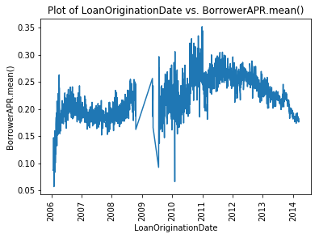

```python
plt.plot(prosper_loandate)
plt.title('Plot of LoanOriginationDate vs. BorrowerAPR.mean()')
plt.xlabel('LoanOriginationDate')
plt.ylabel('BorrowerAPR.mean()')
plt.xticks(rotation='vertical');
```

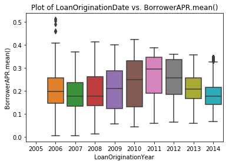

```python
sb.boxplot( data= prosper, x= 'LoanOriginationYear', y = 'BorrowerAPR')
plt.title('Plot of LoanOriginationDate vs. BorrowerAPR.mean()')
plt.xlabel('LoanOriginationYear')
plt.ylabel('BorrowerAPR.mean()')
plt.show();
```

### Plot 5 **AmountDelinquent** (> 30 Delinquent Days )vs. **NewGrade**

The pie chart shows that 73% of Delinquent Amount comes from grades D (21% USD 4.5M), E(22% USD 4.7M) and HR (30% USD 6M). It's really important for Prosper to understand the reason of delinquency. If these delinquent amount can be successfully solved, Prosper could save significant cost for collection and avoid write off on opening loan balance. The potential saving could be USD 15M.

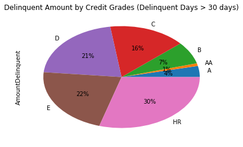

```python
prosper_delinquent = prosper.query('AmountDelinquent != 0 & LoanCurrentDaysDelinquent > 30').groupby('NewGrade').AmountDelinquent.sum()
prosper_delinquent.plot(kind='pie', autopct='%1.0f%%')
plt.title('Delinquent Amount by Credit Grades (Delinquent Days > 30 days)')
plt.xticks(rotation = 90);
```

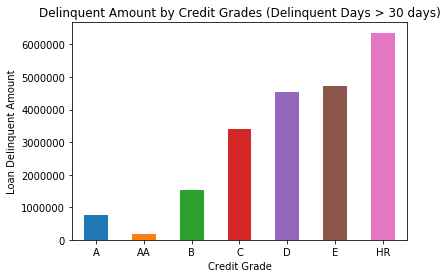

```python
prosper_delinquent.plot(kind='bar')
plt.title('Delinquent Amount by Credit Grades (Delinquent Days > 30 days)')
plt.xlabel('Credit Grade')
plt.ylabel('Loan Delinquent Amount')
plt.xticks(rotation = 0);
```

### Plot 6 **loanprofit** vs. **NewGrade**

The histogram chart indicates that grade C is the most profitable grade, followed B grade B, A, AA and D, while HR and E have negative profit. This result provides Prosper on strategic planning in the future to focus on more profitable borrower type such as grade B and C and avoid grade HR.

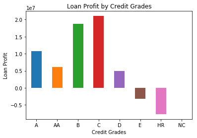

```python
prosper_profit = prosper.groupby('NewGrade').loanprofit.sum()
prosper_profit.plot(kind='bar')
plt.title('Loan Profit by Credit Grades')
plt.xlabel('Credit Grades')
plt.ylabel('Loan Profit')
plt.xticks(rotation = 0);
```

### Plot 7 **LoanOriginalAmount**(LoanStatus =="Defaulted) vs. **NewGrade**

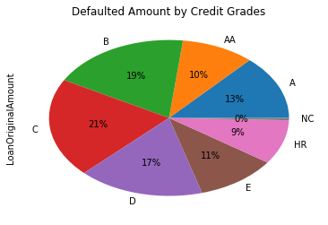

```python
prosper_defaulted_grade = prosper.query('LoanOriginalAmount > 0').sort_values(by ='NewGrade', ascending = False).query('LoanStatus =="Defaulted"').groupby('NewGrade').LoanOriginalAmount.sum()
prosper_defaulted_grade.plot(kind='pie', autopct='%1.0f%%')
plt.title('Defaulted Amount by Credit Grades')
plt.xticks(fontsize=5);
```

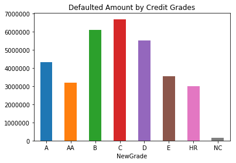

```python
prosper_defaulted_grade = prosper.query('LoanOriginalAmount > 0').sort_values(by ='NewGrade', ascending = False).query('LoanStatus =="Defaulted"').groupby('NewGrade').LoanOriginalAmount.sum()
prosper_defaulted_grade.plot(kind='bar')
plt.title('Defaulted Amount by Credit Grades')
plt.xticks(rotation = 0);
```

### Plot 8 **Defaulted Rate** vs. **BorrowerState**

To understand the ratio of Defaulted Loan, we created a new variable called prosper_defaultratetop10 which provides the top 10 ratio of Defaulted Loan compared to Total Loan amount per state. The formula is :

**LoanOriginalAmount**(LoanStatus =="Defaulted).sum() / **LoanOriginalAmount**.sum() The result shows the states IA (Iowa) and ND (North Dakota) has the highest defaulted ratio (c.a. 13%). Based on previous analysis, we understood that IA and ND are not the states with high amount of business/loan but they have highest defaulted rates. Thus to have better usage on resources and management on delinquency, it's important for Prosper to perhaps eliminate the operation in those states with higher defaulted rate but lower amount of loan/business.

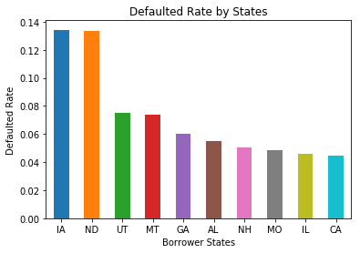

```python
prosper_defaultamount = prosper.query('LoanStatus =="Defaulted"').groupby('BorrowerState').LoanOriginalAmount.sum()
prosper_defaultrate = prosper_defaultamount / prosper.groupby('BorrowerState').LoanOriginalAmount.sum()
prosper_defaultratetop10 = prosper_defaultrate.sort_values(ascending = False).head(10)
prosper_defaultratetop10.plot(kind='bar')
plt.title('Defaulted Rate by States')
plt.xlabel('Borrower States')
plt.ylabel('Defaulted Rate')
plt.xticks(rotation = 0);
```

### Plot 9 **NewGrade**, **LoanOriginalAmount**, **AmountDelinquent** (ReasonableResult == True)

In this scatter plot, we will exclude these exceptions (ReasonableResult == True). It’s interesting to see that:

- Grade HR is mostly with **LoanOriginalAmount** lower than USD 10,000 and **AmountDelinquent** under USD 5,000.
- Grade E is mostly with **LoanOriginalAmount** lower than USD 10,000 and **AmountDelinquent** under USD 10,000.
- Grade D has quite some cases where **LoanOriginalAmount** is USD 10,000/ USD15,000 and **AmountDelinquent** under USD 10,000/ USD 15,000.
- Grade C has quite some cases where **LoanOriginalAmount** is USD 20,000 / USD 25,000 and **AmountDelinquent** under USD 20,000 / USD 25,000.
- Grade B in general has less obvious occurrence of **AmountDelinquent**. However, several cases are also noted that **AmountDelinquent** is spread among USD 5,000 and USD 20,000.

Overall, the higher credit grade with higher approved loan amount indicates also higher amount of delinquent.

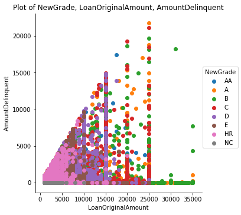

```python
prosper_ReasonableResult = prosper.query('ReasonableResult == True')
NewGradeAmount = sb.FacetGrid(data = prosper_ReasonableResult, hue = 'NewGrade', size = 5, hue_order=['AA','A','B','C','D','E','HR','NC'])
NewGradeAmount.map(plt.scatter, 'LoanOriginalAmount', 'AmountDelinquent')
plt.title('Plot of NewGrade, LoanOriginalAmount, AmountDelinquent')
NewGradeAmount.add_legend();
```

### Plot 10 **BorrowerAPR, DebtToIncomeRatio, LenderYield, IsBorrowerHomeowner, DelinquenciesLast7Years, StatedMonthlyIncome, AmountDelinquent, MonthlyLoanPayment, LoanOriginalAmount, loanprofit,BankcardUtilization, IncomeVerifiable**

In this analysis, we add 12 variables to understand the correlations among each other. There are some moderate correlations (over +- 0.3) noted:

- **AmountDelinquen** has strongly negative relationship with **loanprofit** (-0.99).
- **BorrowerAPR** / **LenderYield** has moderately negative relationship (-0.32 / -0.33) with **LoanOriginalAmount**. In general, there is no surprising relationship is noted based on this analysis. Most relationship is acknowledged in previous discussion.

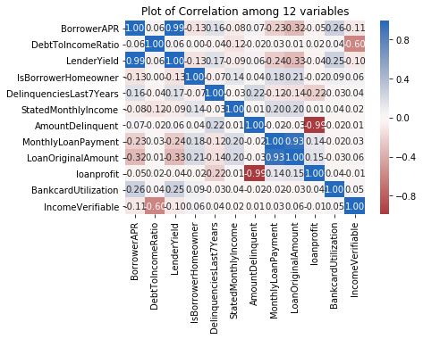

```python
prosper1 = prosper[['BorrowerAPR', 'DebtToIncomeRatio', 'LenderYield','IsBorrowerHomeowner','DelinquenciesLast7Years',
                    'StatedMonthlyIncome','AmountDelinquent','MonthlyLoanPayment','LoanOriginalAmount','loanprofit','BankcardUtilization','IncomeVerifiable']]
sb.heatmap(prosper1.corr(), annot = True, fmt = '.2f', cmap = 'vlag_r', center = 0)
plt.title('Plot of Correlation among 12 variables');
```

## Limitations and Conclusions:

### 1) Limitation:

• As loanprofit is an important element in our analysis, we would like to calculate Profit for each loan according to Yield rate, Original Loan amount and AmountDelinquent. However, it’s noted that 4,635 loans have (much) higher AmountDelinquent than Original Loan amount. It’s important to understand the reason of such deviation. However, due to the insufficient information provided, we can’t explain further about this deviation.

• Moreover, to have deeper analysis on borrowers’ background, Prosper might avoid general categories for borrowers to fill information, such as **occupation** where majority of borrowers fill with Others/Professional.Thus, it's not easy to identify potential borrowers by the type of occupation.

### 2) Conclusion / Actions:

• It’s important for Prosper to investigate the approval process of granting loans with lower credit grades but high loan amount, especially with grades E and HR. The result of analysis on AmountDelinquent indicates that Prosper could possibly avoid loss from loans.

• For those Defaulted loans but with grade AA/A, it’s important for Prosper to investigate further on the reason causing default, so we can reduce the risk of loss. Or Prosper might review the appropriateness of approach of credit grades. Based on these feedback, Prosper can consider new parameters in the future.

• Overall, we can see the borrowers with credit grades C with good profit where majority of borrowers have income between USD 3,000 and USD 5,000. It would be beneficial for Prosper to increase the percentage of such borrowers.